# projekt nr 1

Anna Kozioł

## Cel

Celem projektu jest analiza jednego wybranego spośród zaproponowanych zbioru danych oraz wykonanie zadania predykcji lub klasyfikacji. Niniejszy projekt dotyczy zbioru Mushroom.

## Wstępna analiza

```r
dane <- read.csv("mushrooms.csv", sep = ",")
```

[output not shown]

- Wszystkie zmienne są kategoryczne, najwięcej poziomów posiada zmienna gill.color , z kolei zmienna veil.type przyjmuje stale jedną wartość, z tego powodu zostaje wykluczona z dalszej analizy.
- Zmienna stalk.root przyjmuje wartość równą “?” co może reprezentowaać brak danych, poza tym przypadkiem nie ma innych braków danych w zbiorze.
- zmienna objaśniana- class, jest zrównoważona (dla każdejgo poziomu jest podobna ilość obserwacji)

```r
table(dane$class)
```

```
##
##    e    p
## 4208 3916
```

- Ponieważ mamy do czynienia ze zmiennymi kategorycznymi, jako miarę zależności miedzy zmiennymi można przyjąć tau Godmana-Kruskala . Wartości w komórkach określają miarę tau zależności zmiennej w wierszu do tej w kolumnie.Liczby na diagonali wykresu przedstawiają liczbę poziomów zmiennej. Najciekawszym wynikiem wizualizacji jest bardzo duży współczynnik tau 0.94 sugerujący, że znajomość zmiennej odor (zapach) w bardzo dużym stopniu wpływa na znajomość zmiennej class. W drugą stronę związek zachodzi ale jest wiele słabszy, znając zmiennaą class jesteśmy w stanie w małym stopniu przewidzieć zapach (t = 0.34).

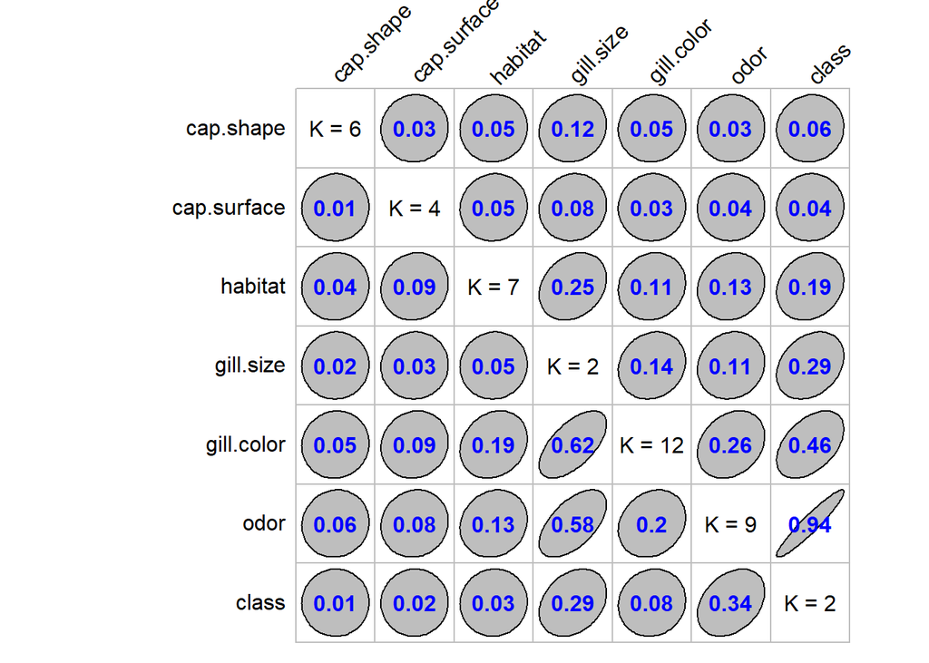

## Model

Ponieważ las losowy dobre radzi sobie z brakami danych w zbiorze, oraz implementacja z pakietu randomForest nie wymaga stosowania one hot encoding, ostatecznym modelem z testowanych wybranym do klasyfikacji jest model lasu losowego z parametrem ntree = 100.

```r
dane <- dane[, -which(names(dane) == "veil.type")]
#podzial na trening i test
smp_size <- floor(0.70 * nrow(dane))
train_ind <- sample(seq_len(nrow(dane)), size = smp_size)
train <- dane[train_ind, ]
test <- dane[-train_ind, ]

rf = randomForest(class ~ .,
                  ntree = 100,
                  data = train)
```

Jakość modelu przedstawia wydruk:

```r
predykcja= predict(rf , test)
confusionMatrix(table(test$class,predykcja))
```

```
## Confusion Matrix and Statistics
##
##    predykcja
##        e    p
##   e 1335    0
##   p    0 1103
##
##                Accuracy : 1
##                  95% CI : (0.9985, 1)
##     No Information Rate : 0.5476
##     P-Value [Acc > NIR] : < 2.2e-16
##
##                   Kappa : 1
##
##  Mcnemar's Test P-Value : NA
##
##             Sensitivity : 1.0000
##             Specificity : 1.0000
##          Pos Pred Value : 1.0000
##          Neg Pred Value : 1.0000
##              Prevalence : 0.5476
##          Detection Rate : 0.5476
##    Detection Prevalence : 0.5476
##       Balanced Accuracy : 1.0000
##
##        'Positive' Class : e
##
```

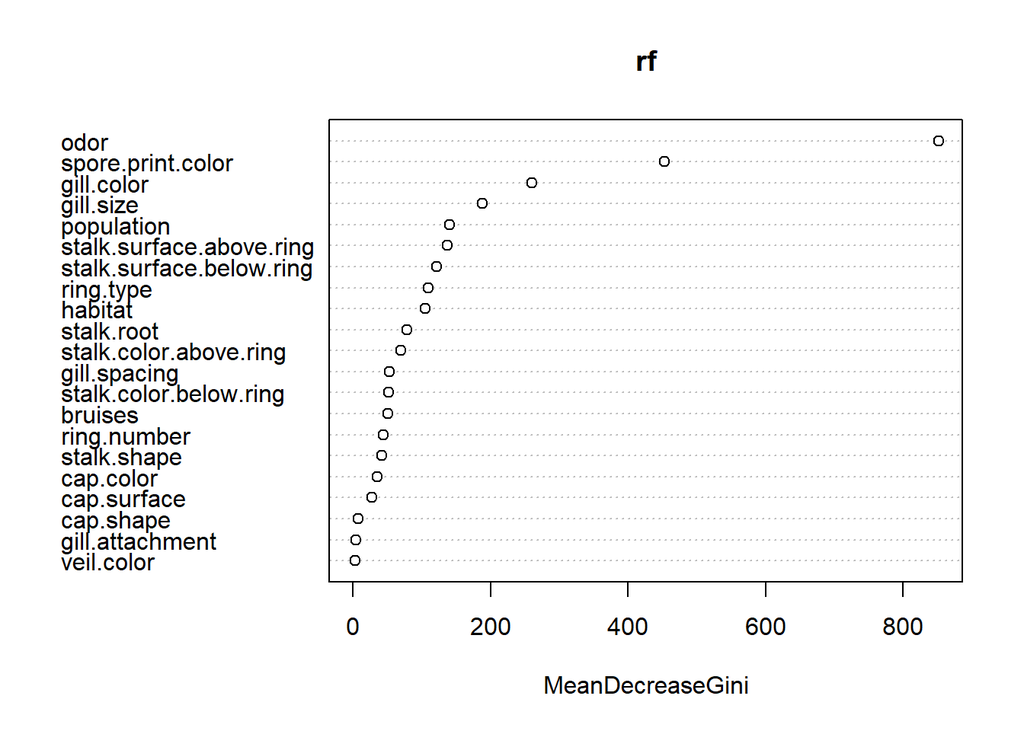

Zgodnie z poprzednią analizą zmienna odor (zapach) znacznie wpływa na wyniki modelu. Kolejnymi zmiennymi okazały się spore.print.color, gill.color.